# Imbalance in Wind Power Generation

Alkım Can Çelik

26.08.2019

### Contents

1. Introduction
2. Key Takeaways
3. Graphs
   1. Comparison of Monthly Imbalance Cost and The Amount of Tolerance in Wind Power Generation
   2. Distribution of Imbalance Quantity Ratios on a Monthly Basis
   3. Daily Imbalance Cost in Wind Power Generation
   4. Hourly Difference between KGÜP and KUDÜP in Wind Power Generation
4. Conclusion
5. References
6. About the Author

### Introduction

This report had been prepared to analyze the imbalance quantities and cost of wind power generation from August 2018 to July 2019. In addition, the true meaning of tolerance and the amount of tolerance in that interval is also discussed in detail.

### Key Takeaways

- Monthly total imbalance cost of wind power generation generally increased in the last year due to the slight rise in the amount of imbalance in wind power generation, which also affects difference between system marginal price and market clearing price.
- Monthly amount of total tolerance for wind power generation had tended to decrease until May 2019. After that, this amount significantly increased.
- Although imbalance quantity ratios of all resources were mostly positive, imbalance quantity ratios in wind power generation varied significantly both positive and negative sides due to its imbalance nature.
- Wind power generation (UEVM) exceeded final daily production program (KGÜP) in 4830 of 8760 hours.
- Companies who are in wind power generation mostly did not change their predictions, but occasionally increased their final daily production program after closing intraday market.
- Imbalance cost varied significantly day by day in the last year due to the instability of wind force. There are lots of peaks located nearby bottoms. This variability slightly increased in the last months compared to the end of 2018.

### Graphs

#### 1) Comparison of Monthly Imbalance Cost and The Amount of Tolerance in Wind Power Generation

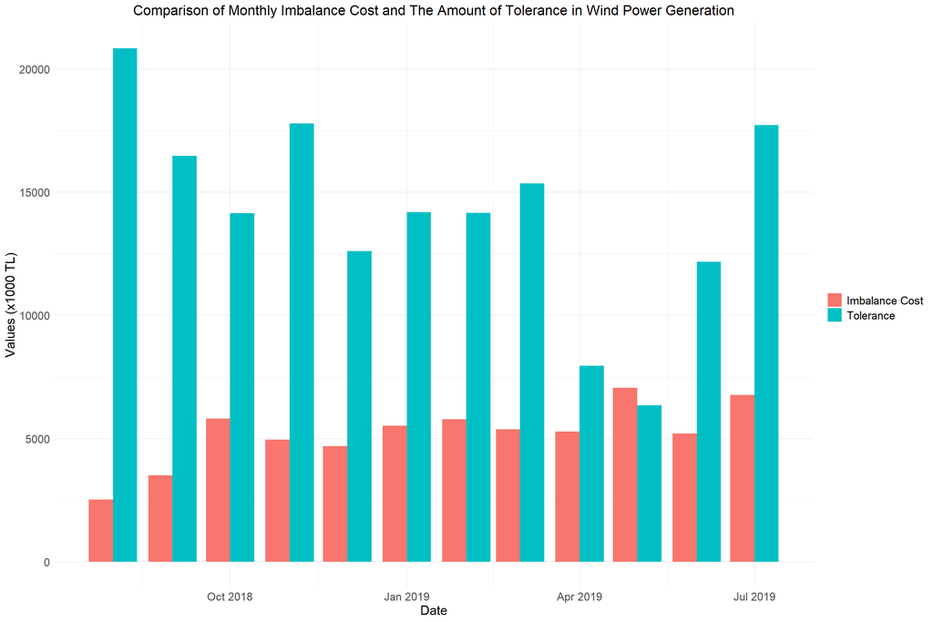

This graph demonstrates monthly total imbalance cost and the amount of tolerance in wind power generation from August 2018 to July 2019.

First of all, monthly imbalance cost generally has increased in the last year. It is hard to determine the reasons of this situation due to considerable variability in wind power generation. There is no significant rise in installed wind capacity, therefore it cannot be a good reason. Time interval may be a reason because wind has the lowest force in summer, and the graph is a good proof for this claim. Wind electricity generation increases in spring and fall.

Moreover, the rise in market clearing price (PTF) must be a powerful argument for imbalance cost of wind electricity generation. When [the report](https://alkimcelik.github.io/Rise_In_Unit_Cost_of_YEKDEM.html#first) written by the author about unit cost of YEKDEM is analyzed, there is a correlation between market clearing price and imbalance cost due to the formula. However, the most fundamental factor affecting the imbalance cost is the difference between final daily production program and real wind energy generation, which also influences system marginal price.

The amount of tolerance indicates revenue coming from EPDK to support organizations who generate electricity. It is like a gift whose worth is determined by their production values.

When the graph above is analyzed, it can be clearly seen that monthly amount of tolerance are significantly higher than the imbalance cost in wind power generation, which stems from the formulas of them. Total production is one of the elements of the EPDK’s tolerance formula. Nevertheless, difference between total production and final daily production program is a part of the formula of imbalance cost. Due to huge difference between these two parts, values of imbalance cost and tolerance diverge significantly from each other.

#### 2) Distribution of Imbalance Quantity Ratios on a Monthly Basis

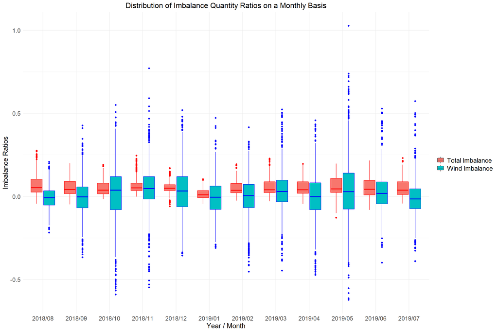

In this graph, imbalance ratios are calculated through how much real wind power generation and real total production (UEVM) diverge from the final daily production program of organizations (KGÜP). If imbalance ratio is positive, generation exceeds the prediction, and vice versa.

When the data is investigated, it can be seen that wind power generation exceeded its organizations’ prediction for 4830 of 8760 hours in the last year, which means organizations have occasionally predicted more than real production.

By contrast with imbalance in total production, wind imbalance ratios varied significantly within each other due to its instable situation. The other resources are more balanced than wind power.

It is obvious to see that total production for all resources generally exceeded predictions. For instance, all hourly predictions except for one hour are lower than the real production in November 2018. There are few predictions for total production being more than real production in the last year. On the contrary, there are lots of higher predictions than real wind power generation. Clearly, its reason is wind’s instability.

#### 3) Daily Imbalance Cost in Wind Power Generation

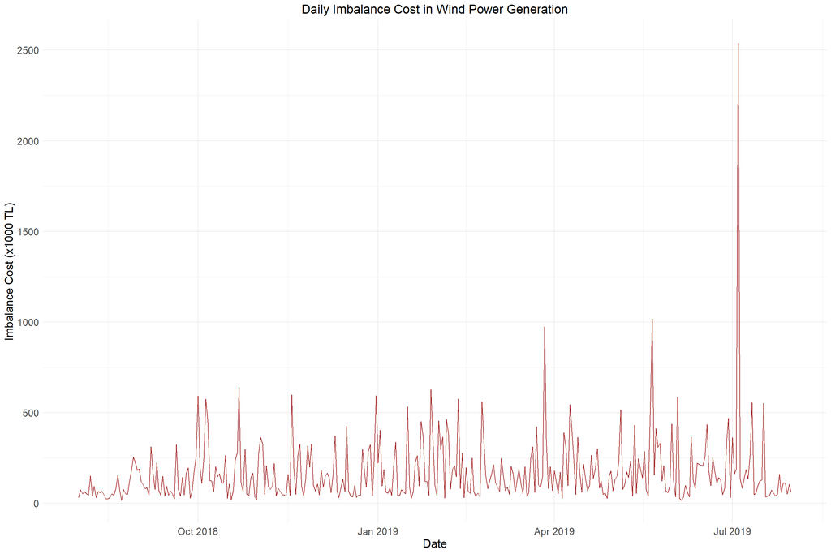

This graph shows daily imbalance cost in wind power production from August 2018 to July 2019.

It can be clearly realized that total imbalance cost of wind power generation varies significantly day by day due to the instability of wind power. Lots of bottoms accompany peaks nearby in this graph.

There are some marginal values, such as in July 2019. When this significant peak is investigated, the reason is extraordinary storms in that summer day. Predictions in day ahead were lower than real production and system marginal prices were also significantly lower than market clearing price, which increases the unit of imbalance cost.

Variability in daily imbalance cost has slightly increased in the last months. Its reason may be global warming, but there is no evidence for that. Fluctuations of market clearing price may be a good reason.

#### 4) Hourly Difference between KGÜP and KUDÜP in Wind Power Generation

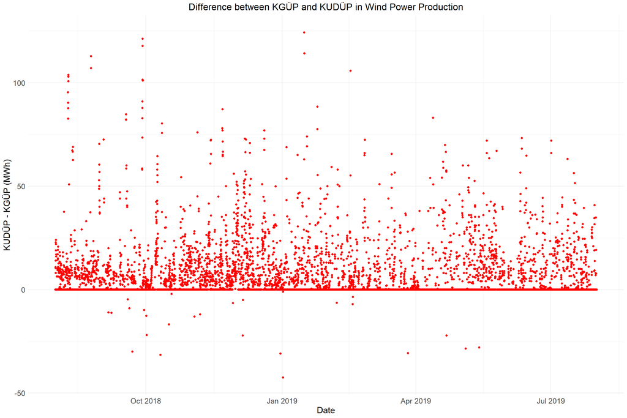

This graph illustrates how the organizations in wind power production change their prediction after closing intraday market in the last year.

It can be clearly realized that companies have tended to increase their prediction made in day-ahead market. When the data is investigated, these organizations, mostly, have not changed or have slightly increased their prediction. There are very few instances for which the organizations have decreased their predictions.

When the above graphs are analyzed, the fact that the number of undescended wind power production is very few is quite interesting because there have been lots of examples for which the prediction is higher than the real wind power generation.

### Conclusion

- Due to the rise in the amount of imbalance in wind power generation, and the rise in market clearing price in the last year, total imbalance cost of wind production on a monthly basis has tended to increase in the last year.
- Monthly the amount of tolerance for wind production had diminished until May 2019, then has significantly increased.
- Imbalance ratios in wind power generation vary significantly due to its unstable nature.
- Organizations generally did not changed their predictions. Sometimes, they increased their predictions.
- Day by day variability in imbalance cost of wind power generation increased after the end of 2018.

### References

https://seffaflik.epias.com.tr/transparency/uretim/planlama/kgup.xhtml

https://seffaflik.epias.com.tr/transparency/uretim/planlama/kudup.xhtml

https://seffaflik.epias.com.tr/transparency/uretim/gerceklesen-uretim/uevm.xhtml

https://seffaflik.epias.com.tr/transparency/piyasalar/gop/ptf.xhtml

https://seffaflik.epias.com.tr/transparency/piyasalar/dgp/smf.xhtml

https://www.cnnturk.com/turkiye/hava-durumu-4-temmuz-firtina-ve-siddetli-ruzgar-uyarisi

### About the Author

Alkım Can Çelik is a data science intern who is currently working on analyzing forecasts of electricity distribution companies, behaviours of market prices, and electricity consumption of cities at Algopoly. He studies Industrial Engineering at Boğaziçi University. He is enthusiastic about data science and analysis, operations research, machine learning applications, and finance.

To contact Alkım, you can send an e-mail to alkimcancelik33@gmail.com or through [Linkedin](https://www.linkedin.com/in/alkimcelik-b8446b131/).

You can reach the author’s other reports via his [GitHub Page](https://alkimcelik.github.io/)